# FigureYa290BarGraph

**Author(s)**: Xiaofan Lu; Yasi Zhang  
**Reviewer(s)**: Ying Ge  
**Date**: 2025-05-20

# 需求描述

# Demand description

想众筹这两个柱状图，重点是不知道一个柱子的不同百分比是怎么做的统计检验。

We want to crowdfund reproduction of these bar graphs, particularly focusing on statistical tests for different percentages within each bar

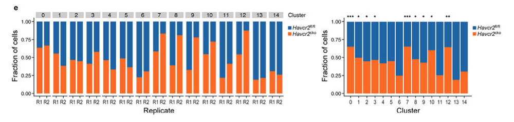

出自https://www.ncbi.nlm.nih.gov/pmc/articles/PMC8627694

扩展数据图4 | Havcr2fl/fl和Havcr2cko CD45+细胞的单细胞RNA测序。(e) 显示每个cluster中Havcr2fl/fl(蓝)和Havcr2cko(橙)细胞比例的柱状图。

Source: https://www.ncbi.nlm.nih.gov/pmc/articles/PMC8627694

Extended Data Fig. 4 |. scRNA-seq of Havcr2fl/fl and Havcr2cko total CD45+ cells. (e) Bar graph showing frequency of Havcr2fl/fl (blue) and Havcr2cko (orange) cells in each cluster.

# 应用场景

# Application scenarios

对单细胞数据进行处理和分型，绘制细胞比例柱状图并做富集检验。

更多单细胞FigureYa看这里https://k.youshop10.com/McawGY6=

The single-cell data were processed and typed, the cell proportion bar chart was drawn and enrichment tests were conducted.

More single-cell FigureYa at: https://k.youshop10.com/McawGY6=

# 环境设置

# Environment Setup

使用国内镜像安装包。

Using domestic mirrors for package installation.

```r
options("repos"= c(CRAN="https://mirrors.tuna.tsinghua.edu.cn/CRAN/"))
options(BioC_mirror="http://mirrors.tuna.tsinghua.edu.cn/bioconductor/")
remotes::install_github("mojaveazure/seurat-disk")
install.packages("hdf5r")
```

# 加载包

# Loading packages

```r
library(ggplot2)
library(rstatix)
library(Seurat)
library(SeuratDisk)
library(Matrix)

# 显示英文报错信息
# Show English error messages
Sys.setenv(LANGUAGE = "en")

# 禁止chr转成factor
# Prevent character-to-factor conversion
options(stringsAsFactors = FALSE)
```

# 输入文件

# Input Files

例文数据已上传至GEO（GSE151914），下载地址：https://www.ncbi.nlm.nih.gov/geo/query/acc.cgi?acc=GSE151914

Data available on GEO (GSE151914), download from: https://www.ncbi.nlm.nih.gov/geo/query/acc.cgi?acc=GSE151914

```r
# 读取count矩阵、细胞Barcode、基因名和细胞对应的样本信息
# Read count matrix, cell barcodes, gene names and sample metadata
mtx <- readMM("GSE151914_expression_matrix.mtx.gz")
cellID <- read.table("GSE151914_cellIDs.txt.gz")
geneID <- read.table("GSE151914_genes.txt.gz")
metadata <- read.table("GSE151914_metadata.txt.gz", header = T, sep = ",")

# 检查count矩阵大小是否与细胞Barcode/基因名一致
# Check matrix dimensions match cell barcode/gene identifiers
dim(mtx)
```

```
## [1] 12638 12458
```

```r
all(metadata$Index == cellID$V1)
```

```
## [1] TRUE
```

```r
# 修改count行列名
# Modify matrix row/column names
rownames(mtx) <- geneID$V1; colnames(mtx) = cellID$V1
summary(rowSums(mtx>0))
```

```
##    Min. 1st Qu.  Median    Mean 3rd Qu.    Max.
##      46     453    1436    2248    3173   12441
```

```r
summary(colSums(mtx>0))
```

```
##    Min. 1st Qu.  Median    Mean 3rd Qu.    Max.
##     499    1282    1838    2280    3095    7531
```

```r
# 制作seurat对象，根据原文该分析只用到肿瘤样本(使用原文的参数 nfeatures = 1000, dim.to.use = 1:12)
# To create the seurat object, according to the original text, this analysis only uses tumor samples (using the original text parameters nfeatures = 1000, dim.to.use = 1:12).
seu <- CreateSeuratObject(mtx)
seu$Sample = metadata$Sample
seu <- subset(seu, Sample %in% c("Tum_963_WT", "Tum_650_KO", "Tum_877_WT", "Tum_685_KO"))
seu <- NormalizeData(seu)
```

```
## Normalizing layer: counts
```

```r
# 寻找高变异基因
# Find HVGs
seu <- FindVariableFeatures(seu, nfeatures = 1000)
```

```
## Finding variable features for layer counts
```

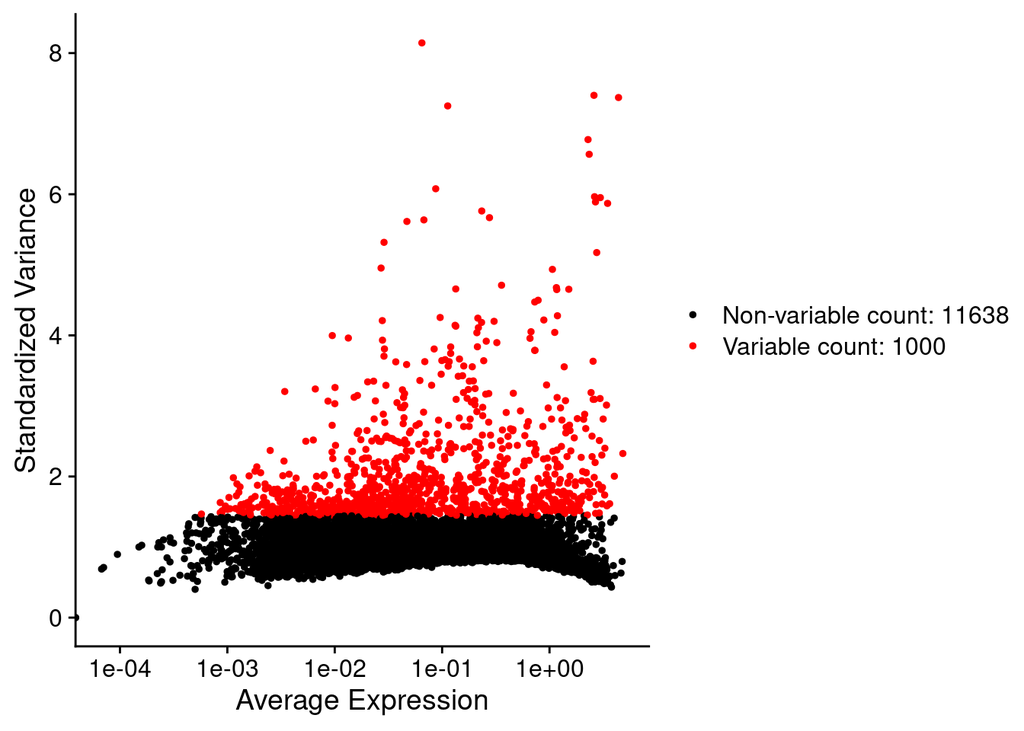

```r
# 可视化高变异基因
# Visualize HVGs
VariableFeaturePlot(seu)
```

```r
# 标准化
# Standardization
seu <- ScaleData(seu)
# 降维
# Dimensionality reduction
seu <- RunPCA(seu)
```

```
## PC_ 1
## Positive:  Il2rb, Lck, Gimap4, Ptprcap, Thy1, Nkg7, Sh2d2a, Gimap3, Sept1, Gimap1
##     Cd2, Skap1, Gimap5, Tigit, Ctsw, Zap70, Gimap6, Cd3g, Tnfrsf18, Ms4a4b
##     Cd3e, Cd3d, Gzmb, Lat, Cd247, Icos, Klrc1, Fasl, Gimap7, Ltb
## Negative:  Tgfbi, Lyz2, Alox5ap, Csf1r, Cd68, Ifitm3, Ctsh, Ms4a6c, Fcgr3, Fcgr2b
##     Fcer1g, Grn, Fcgr1, Pld4, Tyrobp, Ctss, Lgmn, Ms4a6d, Ifi30, Aif1
##     Mafb, Unc93b1, Apoe, Ctsc, Cxcl16, Fcgr4, Ly86, Plbd1, Cybb, Psap
## PC_ 2
## Positive:  Plac8, Ifitm6, Hp, Chil3, Ly6c2, Gsr, Adgre5, Pim1, Gm9733, Nr4a1
##     Btg2, Il1b, Lsp1, Samhd1, Slpi, Mcemp1, Ace, Junb, Ly6i, Csrnp1
##     Zfp36, Cd177, Ier2, Emilin2, Napsa, Cytip, Nfe2, Ceacam1, Adgre4, Pde4b
## Negative:  Cd81, C1qa, C1qc, C1qb, Ms4a7, Cd72, Olfml3, Cd63, Gatm, Slamf9
##     Stmn1, Timp2, Mif, Lgals1, Ntpcr, AW112010, Cxcl14, Rgs1, Tmem119, Mt1
##     Tubb5, Ccl7, Ccl12, Igfbp4, Tk1, Cks1b, Dut, Birc5, Ckb, Pf4
## PC_ 3
## Positive:  Capg, Glrx, Srgn, Ctsd, Ly6a, Grina, Ms4a6d, C3ar1, Smox, Slc2a1
##     AW112010, Lilrb4a, AA467197, C5ar1, Ccr1, Rgs1, Adam8, Il7r, Cd3g, Tnfrsf9
##     Fcgr3, Cd3e, Tpi1, Cd3d, Cst7, Fcgr1, Icos, Cxcr6, Tigit, Clec4n
## Negative:  Serpinf1, Col6a1, Col3a1, Scd1, Col6a2, Serpinh1, Rhox5, Ebf1, Dcn, Cd34
##     Sparc, Siglecg, Pcolce, Aebp1, Tm4sf1, Htra1, Fstl1, Prkcdbp, Cd19, Sox9
##     Ms4a1, Fgfr1, Gpx8, Cd79a, Tpm2, Cald1, Fcmr, mt-Nd1, Mzb1, Matn2
## PC_ 4
## Positive:  Col6a2, Col6a1, Fstl1, Pcolce, Ppic, Htra1, Gpx8, Dcn, Serpinh1, Aebp1
##     Col3a1, Sparc, Sdc2, Tm4sf1, Sox9, Prkcdbp, S100a6, Inhba, Plod2, Cav1
##     Cald1, Rhox5, Col6a3, Hoxc10, Rgcc, Anxa2, Col5a1, Matn2, Fbn1, Serpinf1
## Negative:  H2-Eb1, H2-Aa, H2-Ob, H2-DMb2, Cd74, Cd79a, H2-Ab1, H2-DMa, Ms4a1, Cd79b
##     Fcmr, Ly86, H2-Oa, Ly6d, Cd19, Fcer2a, Siglecg, Cd72, Mzb1, H2-DMb1
##     Bank1, Ebf1, Ckb, Tnfrsf13c, Blk, Btla, Ctss, Bcl11a, Unc93b1, Cd83
## PC_ 5
## Positive:  Cd79a, Ccr7, Ms4a1, Ebf1, Fcmr, Ly6d, Cd19, Fcer2a, Cd24a, Snn
##     Siglecg, Mzb1, Cd200, Blk, H2-Ob, Zfp36l1, Bank1, Cxcr5, Tnfrsf4, Tnfrsf13c
##     Gadd45b, Mreg, Il7r, Vpreb3, Il4i1, Cacnb3, Ccl22, H2-DMb2, Hilpda, H2-Oa
## Negative:  Ncr1, Klrb1c, Gzma, Eomes, Klrb1f, Klre1, Klra7, Klra8, Fcer1g, Ace
##     Clec4a3, Adgre4, Klrb1a, Gm9733, Spn, S1pr5, Prf1, Xcl1, Serpinb10, Serpinb2
##     Car2, Txk, Cx3cr1, Pdlim1, Ifitm10, Klra9, Ctsw, Ear2, Fasl, Klrc2
```

```r
dim.to.use = 1:12
seu <- RunUMAP(seu, dims = dim.to.use)
```

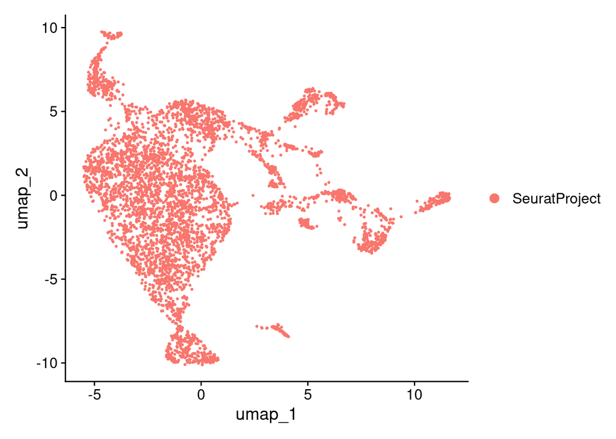

```r
DimPlot(seu)
```